# Rapportage regeling werkverdeling

Planning en Roostering

19 april 2021

## Regeling werkverdeling, in het kort

Dit document doet verslag van de uitvoering van de regeling op basis van de registraties in Xedule.Voor de medewerker die deel uitmaakt van een onderwijsteam (direct betrokken bij het primair proces en benoemd in een functie met carrièrepatroon 7 of hoger) geldt een inzetbaarheidskader. Dit kader houdt bij een normbetrekking in, dat de normjaartaak van 1659 uur als volgt is gecompartimenteerd op teamniveau:  
- 1200 uur voor die werkzaamheden die verband houden met de uitvoering van het onderwijs en de direct daaruit voortkomende werkzaamheden;  
- 459 uur voor die werkzaamheden die verband houden met de organisatie en ontwikkeling van het onderwijs, waaronder professionalisering, overleg, afstemming en coördinatie.

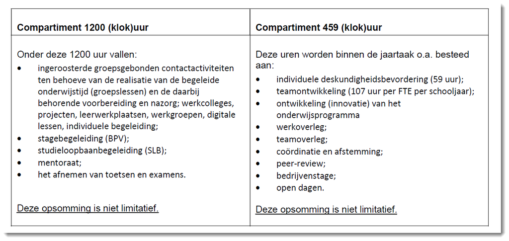

Het onderwijsteam kan besluiten om af te wijken van het inzetbaarheidskader van 1200-459 uur per medewerker. Dit leidt tot een andere compartimentering van taken en verdeling over de teamleden. In een schriftelijke stemming van een onderwijsteam wordt hiertoe unaniem besloten.

# Registratie op collegeniveau

**Registratie in Xedule**

De eerder genoemde compartimenten worden conform de regeling geregistreerd in Xedule. We kijken allereerst naar de volledigheid van de registraties per compartiment. In tabel 1 zien we dat 88 % van de geplande taken behorend bij compartiment 1200 zijn geregistreerd. In compartiment 459 is 66% van de geplande taken geregistreerd.

**Tabel:1 Overzicht volledige en onvolledige registraties in Xedule per college**

| college | Compartiment (1200 uur) Niet | Compartiment (1200 uur) Wel | Totaal |
| --- | --- | --- | --- |
| CEO | 25 (8%) | 283 (92%) | 308 (100%) |
| CSP | 8 (5%) | 147 (95%) | 155 (100%) |
| HOS | 24 (19%) | 100 (81%) | 124 (100%) |
| LSE | 18 (13%) | 116 (87%) | 134 (100%) |
| Start | 25 (20%) | 98 (80%) | 123 (100%) |
| ZOC | 47 (12%) | 356 (88%) | 403 (100%) |
| Totaal | 147 (12%) | 1100 (88%) | 1247 (100%) |

<sup>a</sup> Percentages zijn horizontaal berekend, geven aan welk deel geregistreerd is  
<sup>b</sup> kleine correctie toegepast op inhoudelijk onlogische registraties

| college | Compartiment (459 uur) NA | Compartiment (459 uur) Niet | Compartiment (459 uur) Wel | Totaal |
| --- | --- | --- | --- | --- |
| CEO | 1 (0%) | 64 (20%) | 248 (79%) | 313 (100%) |
| CSP | 0 (0%) | 20 (13%) | 135 (87%) | 155 (100%) |
| HOS | 0 (0%) | 25 (20%) | 100 (80%) | 125 (100%) |
| LSE | 0 (0%) | 48 (35%) | 88 (65%) | 136 (100%) |
| Start | 0 (0%) | 81 (65%) | 44 (35%) | 125 (100%) |
| ZOC | 0 (0%) | 191 (46%) | 227 (54%) | 418 (100%) |
| Totaal | 1 (0%) | 429 (34%) | 842 (66%) | 1272 (100%) |

<sup>a</sup> Percentages zijn horizontaal berekend

Tot zover de registratie. Om een beeld te krijgen van de feitelijke werkverdeling kijken we in de analyses hierna naar de bezettingsgraad.

# Bezettingsgraad per college

## Compartiment 1200 uur

De bezettingsgraad is gedefinieerd als de geplande onderwijstijd afgezet tegen de norm.

$\displaystyle \frac{onderwijstijd}{norm}=bezettingsgraad(1200)$

Daarbij wordt de norm voor onderwijstijd van 1200 uur gewogen met de functie-omvang.  
Dus:

$fte\times 1200=norm$ (bij een halve fte is de norm bijvoorbeeld 600)

We maken gebruik van volledige registratie binnen het compartiment 1200 (klok)uren, m.a.w.: contacttijd en onverige onderwijstijd, docenten van wie deze tijden niet zijn ingevuld vallen buiten de analyse.Daarnaast moet een medewerker individule scholing hebben (59 uur, gewogen met fte). Een bezettingsgraad hoger dan 1,5 laten we buiten beschouwing (komt een enkele keer voor, maar is niet logisch).

In de tabel hieronder zijn de bezettingsgraden ondergebracht in categorieën. Hierdoor krijgt men een goed beeld van de verdeling.De eerste kolom, [0-0.5], laat zien hoeveel docenten minder dan helft voor onderwijstijd zijn ingepland. Kolom [1.1-1.5] laat zien waar de bezetting over de norm heen gaat.

*NB: Het gaat in deze overzichten over registraties van geplande inzetten, de werkelijkheid kan hier natuurlijk van afwijken.*

**Tabel 2: aantal medewerkers per college uitgesplitst naar bezettingsgraad.**

| college | Categorieën bezettingsgraad (comp. 1200) [0, 0.5) | Categorieën bezettingsgraad (comp. 1200) [0.5, 0.9) | Categorieën bezettingsgraad (comp. 1200) [0.9, 1.1) | Categorieën bezettingsgraad (comp. 1200) [1.1, 1.5] | Totaal |
| --- | --- | --- | --- | --- | --- |
| CEO | 78 (29%) | 139 (51%) | 33 (12%) | 23 (8%) | 273 (100%) |
| CSP | 70 (48%) | 57 (39%) | 11 (8%) | 8 (5%) | 146 (100%) |
| HOS | 44 (44%) | 47 (47%) | 6 (6%) | 2 (2%) | 99 (100%) |
| LSE | 29 (26%) | 44 (39%) | 30 (27%) | 9 (8%) | 112 (100%) |
| Start | 24 (24%) | 51 (52%) | 20 (20%) | 3 (3%) | 98 (100%) |
| ZOC | 113 (32%) | 170 (49%) | 34 (10%) | 31 (9%) | 348 (100%) |
| Totaal | 358 (33%) | 508 (47%) | 134 (12%) | 76 (7%) | 1076 (100%) |

<sup>a</sup> Bijvoorbeeld: kolom [0,0.5] laat zien hoeveel medewekers voor maxmaal de helft met taken zijn belast.  
<sup>b</sup> kolom [1.1,1.5] geeft een beeld van medewerkers die boven de norm zijn ingezet.

**Relatie tussen overige onderwijstijd en contacttijd** Om de betrouwbaarbaarheid van de waarnemingen te verifiëren dient er een relatie tussen overige onderwijstijd en contacttijd te zijn. De grafieken hierna geven een beeld van overige onderwijstijd (vertical as) in relatie tot de contacttijd (horizontale as). De relatie heeft te maken met de opslag van 40% op de contacttijd voor voor- en nazorg. Naast die 40 % zijn er nog wat onderwijskundige taken. De overige onderwijstijd is gemiddeld 53% van de contacttijd. *NB: bij ZOC de hoge overige onderwijstijd bij 0 uren contacttijd verifiëren. Tevens de relatief hoge overige onderwijstijd bij LSE nagaan.*

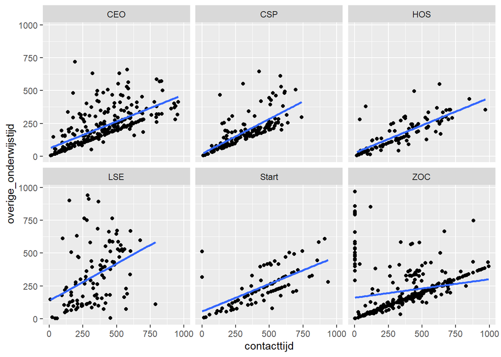

Figuur 1.Overige onderwijstijd versus contacttijd.

**Spreiding bezettingsgraad binnen colleges**

De illustratie hieronder laat in een compacte vorm zien hoe de onderwijstijd in een college is verdeeld. Een punt in de grafiek is de bezettingsgraad per docent. In de boxen staat de gemiddelde bezettingsgraad per college vermeld.

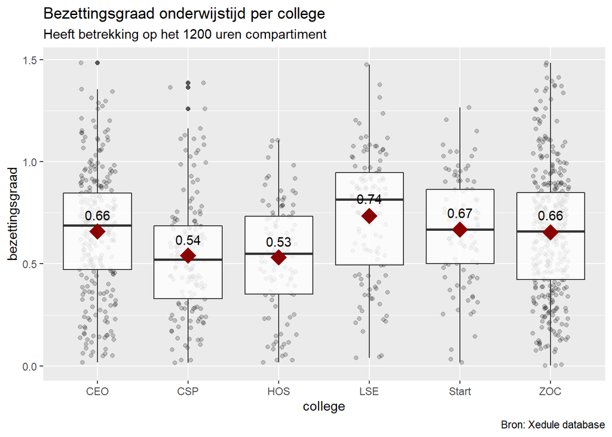

Figuur 2: Boxplot bezettingsgraad per college.

## Compartiment 459 uur

Ook de bezettingsgraad van het tweede compariment kan worden berekend.

$\displaystyle \frac{OverigeTijd }{norm}=bezettingsgraad(459)$

Hiet wegen we de norm voor overige tijd van 459 klokuur met de functie-omvang.  
Dus:

$fte\times 459=norm$ (bij bijvoorbeeld 0,5 fte is de norm 229,5)

We laten hier alleen de de illustraties zien. In de illustratie hieronder wotden de bezettingsgraden van het tweede compartiment boorgesteld als een punt. Het gemiddelde is weergegeven met vierkanten.

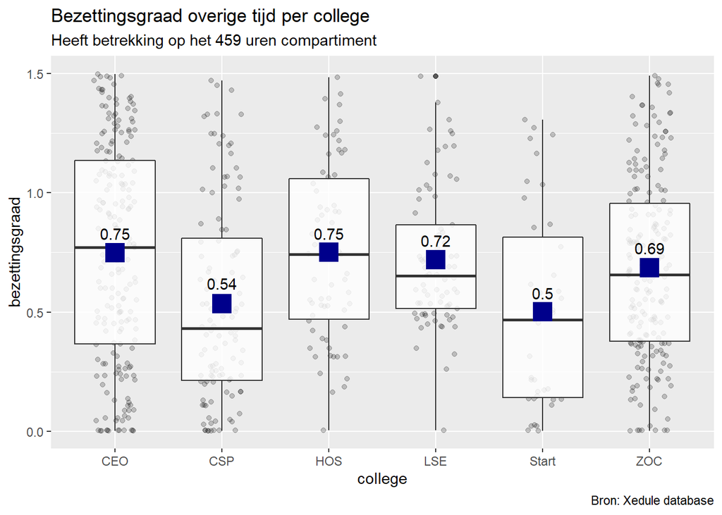

Figuur 3: Boxplot bezettingsgraad 459 per college.

# Analyse op teamniveau, registraties

Dezelfde tabellen als hierboven, maar nu per onderwijsteam.

**Tabel 4a en 4b: Overzicht volledige en onvolledige registraties in Xedule per team**

| team | Compartiment (1200 uur) Niet | Compartiment (1200 uur) Wel | Totaal |
| --- | --- | --- | --- |
| ADC-Team-Dans-RSS-ZVP | 0 (0%) | 8 (100%) | 8 (100%) |
| ASC-Team-Entree AT-BLJ | 1 (5%) | 19 (95%) | 20 (100%) |
| ASC-Team-Entree-BLJ | 3 (14%) | 18 (86%) | 21 (100%) |
| ASC-Team-Entree-BLL | 7 (33%) | 14 (67%) | 21 (100%) |
| ASC-Team-Entree-DV-HOR-DET-SPL | 3 (25%) | 9 (75%) | 12 (100%) |
| ASC-Team-Entree-FZL | 0 (0%) | 6 (100%) | 6 (100%) |
| ASC-Team-Entree-TECH-LOG-SPL | 1 (6%) | 17 (94%) | 18 (100%) |
| BFC-Team-Haarverz-SPL-DVL | 8 (32%) | 17 (68%) | 25 (100%) |
| BFC-Team-Mode-SPL | 2 (10%) | 18 (90%) | 20 (100%) |
| BFC-Team-Schoonheidsv-SPL | 5 (20%) | 20 (80%) | 25 (100%) |
| CEO-Team S&A-FZL | 2 (14%) | 12 (86%) | 14 (100%) |
| CEO-Team-BBL-SPW | 2 (17%) | 10 (83%) | 12 (100%) |
| CEO-Team-DL-HSS | 3 (15%) | 17 (85%) | 20 (100%) |
| CEO-Team-Detailh 1 2-SPW | 2 (9%) | 21 (91%) | 23 (100%) |
| CEO-Team-Detailh 3 4-SPW | 1 (6%) | 15 (94%) | 16 (100%) |
| CEO-Team-FA-WEE-HSS | 1 (5%) | 19 (95%) | 20 (100%) |
| CEO-Team-Handel-ZHP | 0 (0%) | 25 (100%) | 25 (100%) |
| CEO-Team-Hndl SEC ADM-BLL | 2 (10%) | 19 (90%) | 21 (100%) |
| CEO-Team-Hndl SEC ADM-EPA | 6 (24%) | 19 (76%) | 25 (100%) |
| CEO-Team-IBS BVW-ZHP | 2 (8%) | 23 (92%) | 25 (100%) |
| CEO-Team-IH GH-SPW | 0 (0%) | 14 (100%) | 14 (100%) |
| CEO-Team-Juridisch-WEE | 2 (6%) | 30 (94%) | 32 (100%) |
| CEO-Team-MMC-SPW | 1 (5%) | 21 (95%) | 22 (100%) |
| CEO-Team-Niveau 2-WEE | 0 (0%) | 16 (100%) | 16 (100%) |
| CEO-Team-SEC-WEE | 0 (0%) | 11 (100%) | 11 (100%) |
| CEO-Team-Sprint IEMS-ZHP | 1 (8%) | 11 (92%) | 12 (100%) |
| CMP-Team-Muziek-ABW | 0 (0%) | 6 (100%) | 6 (100%) |
| CSP-Team-OA-RSS | 3 (8%) | 33 (92%) | 36 (100%) |
| CSP-Team-PW-ALX | 2 (6%) | 29 (94%) | 31 (100%) |
| CSP-Team-PW-BLL | 1 (5%) | 20 (95%) | 21 (100%) |
| CSP-Team-PW-RSS | 0 (0%) | 31 (100%) | 31 (100%) |
| CSP-Team-SW-WEE | 2 (6%) | 34 (94%) | 36 (100%) |
| FVC-Team-FD-HSS | 0 (0%) | 11 (100%) | 11 (100%) |
| FVC-Team-VH-HSS | 0 (0%) | 14 (100%) | 14 (100%) |
| HOC-Team-BB-RSS | 0 (0%) | 7 (100%) | 7 (100%) |
| HOC-Team-Horeca-BLJ | 4 (22%) | 14 (78%) | 18 (100%) |
| HOC-Team-Horeca-RSS | 5 (26%) | 14 (74%) | 19 (100%) |
| HOC-Team-Maasluis-DVL | 13 (76%) | 4 (24%) | 17 (100%) |
| MTS-Team-Theater-PHW | 1 (100%) | 0 (0%) | 1 (100%) |
| SPC-Team-Sport-ZVP | 2 (4%) | 47 (96%) | 49 (100%) |
| TLC-Team-Leisure-RSS | 2 (14%) | 12 (86%) | 14 (100%) |
| TLC-Team-Travel-ZHP | 0 (0%) | 24 (100%) | 24 (100%) |
| Taal & Inburgering | 10 (40%) | 15 (60%) | 25 (100%) |
| ZOC-Team-AA-RSS | 2 (13%) | 13 (87%) | 15 (100%) |
| ZOC-Team-DA-RSS | 2 (20%) | 8 (80%) | 10 (100%) |
| ZOC-Team-DV MZ-BLL | 0 (0%) | 13 (100%) | 13 (100%) |
| ZOC-Team-DV MZ-TBL | 3 (10%) | 28 (90%) | 31 (100%) |
| ZOC-Team-DV-ALX | 4 (22%) | 14 (78%) | 18 (100%) |
| ZOC-Team-DVA-RSS | 1 (3%) | 28 (97%) | 29 (100%) |
| ZOC-Team-DVB-RSS | 0 (0%) | 18 (100%) | 18 (100%) |
| ZOC-Team-MZ BBL-RSS | 2 (11%) | 16 (89%) | 18 (100%) |
| ZOC-Team-MZ-ALX | 1 (5%) | 20 (95%) | 21 (100%) |
| ZOC-Team-MZ-RSS | 2 (6%) | 32 (94%) | 34 (100%) |
| ZOC-Team-PGL DV-RSS | 1 (20%) | 4 (80%) | 5 (100%) |
| ZOC-Team-VIG BBL-RSS | 4 (19%) | 17 (81%) | 21 (100%) |
| ZOC-Team-VIG BOL-RSS | 3 (19%) | 13 (81%) | 16 (100%) |
| ZOC-Team-VIG MZ PO-RSS | 0 (0%) | 16 (100%) | 16 (100%) |
| ZOC-Team-VIG-ALX | 1 (3%) | 28 (97%) | 29 (100%) |
| ZOC-Team-VO-RSS | 11 (100%) | 0 (0%) | 11 (100%) |
| ZOC-Team-VP-ALX | 1 (6%) | 15 (94%) | 16 (100%) |
| ZOC-Team-VP-AWD | 2 (10%) | 19 (90%) | 21 (100%) |
| ZOC-Team-VP-RSS | 0 (0%) | 22 (100%) | 22 (100%) |
| ZOC-Team-Werkplekleren-RSS | 2 (18%) | 9 (82%) | 11 (100%) |
| ZOC-Team-Zorgcontract | 5 (18%) | 23 (82%) | 28 (100%) |
| Totaal | 147 (12%) | 1100 (88%) | 1247 (100%) |

<sup>a</sup> Percentages zijn horizontaal berekend, geven aan welk deel geregistreerd is

| team | Compartiment (459 uur) NA | Compartiment (459 uur) Niet | Compartiment (459 uur) Wel | Totaal |
| --- | --- | --- | --- | --- |
| ADC-Team-Dans-RSS-ZVP | 0 (0%) | 0 (0%) | 8 (100%) | 8 (100%) |
| ASC-Team-Entree AT-BLJ | 0 (0%) | 2 (10%) | 19 (90%) | 21 (100%) |
| ASC-Team-Entree-BLJ | 0 (0%) | 21 (100%) | 0 (0%) | 21 (100%) |
| ASC-Team-Entree-BLL | 0 (0%) | 21 (100%) | 0 (0%) | 21 (100%) |
| ASC-Team-Entree-DV-HOR-DET-SPL | 0 (0%) | 3 (23%) | 10 (77%) | 13 (100%) |
| ASC-Team-Entree-FZL | 0 (0%) | 6 (100%) | 0 (0%) | 6 (100%) |
| ASC-Team-Entree-TECH-LOG-SPL | 0 (0%) | 18 (100%) | 0 (0%) | 18 (100%) |
| BFC-Team-Haarverz-SPL-DVL | 0 (0%) | 25 (100%) | 0 (0%) | 25 (100%) |
| BFC-Team-Mode-SPL | 0 (0%) | 4 (19%) | 17 (81%) | 21 (100%) |
| BFC-Team-Schoonheidsv-SPL | 0 (0%) | 8 (31%) | 18 (69%) | 26 (100%) |
| CEO-Team S&A-FZL | 0 (0%) | 2 (14%) | 12 (86%) | 14 (100%) |
| CEO-Team-BBL-SPW | 0 (0%) | 1 (8%) | 11 (92%) | 12 (100%) |
| CEO-Team-DL-HSS | 0 (0%) | 2 (10%) | 18 (90%) | 20 (100%) |
| CEO-Team-Detailh 1 2-SPW | 0 (0%) | 5 (22%) | 18 (78%) | 23 (100%) |
| CEO-Team-Detailh 3 4-SPW | 0 (0%) | 6 (38%) | 10 (62%) | 16 (100%) |
| CEO-Team-FA-WEE-HSS | 0 (0%) | 2 (10%) | 19 (90%) | 21 (100%) |
| CEO-Team-Handel-ZHP | 0 (0%) | 0 (0%) | 25 (100%) | 25 (100%) |
| CEO-Team-Hndl SEC ADM-BLL | 0 (0%) | 1 (5%) | 20 (95%) | 21 (100%) |
| CEO-Team-Hndl SEC ADM-EPA | 0 (0%) | 3 (12%) | 22 (88%) | 25 (100%) |
| CEO-Team-IBS BVW-ZHP | 0 (0%) | 3 (12%) | 22 (88%) | 25 (100%) |
| CEO-Team-IH GH-SPW | 0 (0%) | 15 (100%) | 0 (0%) | 15 (100%) |
| CEO-Team-Juridisch-WEE | 0 (0%) | 14 (42%) | 19 (58%) | 33 (100%) |
| CEO-Team-MMC-SPW | 1 (4%) | 5 (22%) | 17 (74%) | 23 (100%) |
| CEO-Team-Niveau 2-WEE | 0 (0%) | 2 (12%) | 14 (88%) | 16 (100%) |
| CEO-Team-SEC-WEE | 0 (0%) | 1 (8%) | 11 (92%) | 12 (100%) |
| CEO-Team-Sprint IEMS-ZHP | 0 (0%) | 2 (17%) | 10 (83%) | 12 (100%) |
| CMP-Team-Muziek-ABW | 0 (0%) | 6 (100%) | 0 (0%) | 6 (100%) |
| CSP-Team-OA-RSS | 0 (0%) | 5 (14%) | 31 (86%) | 36 (100%) |
| CSP-Team-PW-ALX | 0 (0%) | 4 (13%) | 27 (87%) | 31 (100%) |
| CSP-Team-PW-BLL | 0 (0%) | 1 (5%) | 20 (95%) | 21 (100%) |
| CSP-Team-PW-RSS | 0 (0%) | 2 (6%) | 29 (94%) | 31 (100%) |
| CSP-Team-SW-WEE | 0 (0%) | 8 (22%) | 28 (78%) | 36 (100%) |
| FVC-Team-FD-HSS | 0 (0%) | 1 (9%) | 10 (91%) | 11 (100%) |
| FVC-Team-VH-HSS | 0 (0%) | 3 (21%) | 11 (79%) | 14 (100%) |
| HOC-Team-BB-RSS | 0 (0%) | 1 (14%) | 6 (86%) | 7 (100%) |
| HOC-Team-Horeca-BLJ | 0 (0%) | 2 (11%) | 16 (89%) | 18 (100%) |
| HOC-Team-Horeca-RSS | 0 (0%) | 0 (0%) | 19 (100%) | 19 (100%) |
| HOC-Team-Maasluis-DVL | 0 (0%) | 17 (100%) | 0 (0%) | 17 (100%) |
| MTS-Team-Theater-PHW | 0 (0%) | 1 (100%) | 0 (0%) | 1 (100%) |
| SPC-Team-Sport-ZVP | 0 (0%) | 4 (8%) | 45 (92%) | 49 (100%) |
| TLC-Team-Leisure-RSS | 0 (0%) | 1 (7%) | 13 (93%) | 14 (100%) |
| TLC-Team-Travel-ZHP | 0 (0%) | 0 (0%) | 25 (100%) | 25 (100%) |
| Taal & Inburgering | 0 (0%) | 10 (40%) | 15 (60%) | 25 (100%) |
| ZOC-Team-AA-RSS | 0 (0%) | 14 (88%) | 2 (12%) | 16 (100%) |
| ZOC-Team-DA-RSS | 0 (0%) | 9 (82%) | 2 (18%) | 11 (100%) |
| ZOC-Team-DV MZ-BLL | 0 (0%) | 5 (33%) | 10 (67%) | 15 (100%) |
| ZOC-Team-DV MZ-TBL | 0 (0%) | 31 (100%) | 0 (0%) | 31 (100%) |
| ZOC-Team-DV-ALX | 0 (0%) | 5 (28%) | 13 (72%) | 18 (100%) |
| ZOC-Team-DVA-RSS | 0 (0%) | 3 (10%) | 26 (90%) | 29 (100%) |
| ZOC-Team-DVB-RSS | 0 (0%) | 5 (20%) | 20 (80%) | 25 (100%) |
| ZOC-Team-MZ BBL-RSS | 0 (0%) | 2 (11%) | 16 (89%) | 18 (100%) |
| ZOC-Team-MZ-ALX | 0 (0%) | 1 (5%) | 21 (95%) | 22 (100%) |
| ZOC-Team-MZ-RSS | 0 (0%) | 2 (6%) | 32 (94%) | 34 (100%) |
| ZOC-Team-PGL DV-RSS | 0 (0%) | 1 (20%) | 4 (80%) | 5 (100%) |
| ZOC-Team-VIG BBL-RSS | 0 (0%) | 22 (100%) | 0 (0%) | 22 (100%) |
| ZOC-Team-VIG BOL-RSS | 0 (0%) | 16 (100%) | 0 (0%) | 16 (100%) |
| ZOC-Team-VIG MZ PO-RSS | 0 (0%) | 18 (100%) | 0 (0%) | 18 (100%) |
| ZOC-Team-VIG-ALX | 0 (0%) | 2 (7%) | 27 (93%) | 29 (100%) |
| ZOC-Team-VO-RSS | 0 (0%) | 11 (100%) | 0 (0%) | 11 (100%) |
| ZOC-Team-VP-ALX | 0 (0%) | 4 (25%) | 12 (75%) | 16 (100%) |
| ZOC-Team-VP-AWD | 0 (0%) | 7 (33%) | 14 (67%) | 21 (100%) |
| ZOC-Team-VP-RSS | 0 (0%) | 0 (0%) | 22 (100%) | 22 (100%) |
| ZOC-Team-Werkplekleren-RSS | 0 (0%) | 5 (45%) | 6 (55%) | 11 (100%) |
| ZOC-Team-Zorgcontract | 0 (0%) | 28 (100%) | 0 (0%) | 28 (100%) |
| Totaal | 1 (0%) | 429 (34%) | 842 (66%) | 1272 (100%) |

<sup>a</sup> Percentages zijn horizontaal berekend

# Bezettingsgraden per team

| team | Categorieën bezettingsgraad (comp. 1200) [0, 0.5) | Categorieën bezettingsgraad (comp. 1200) [0.5, 0.9) | Categorieën bezettingsgraad (comp. 1200) [0.9, 1.1) | Categorieën bezettingsgraad (comp. 1200) [1.1, 1.5] | Totaal |
| --- | --- | --- | --- | --- | --- |
| ADC-Team-Dans-RSS-ZVP | 4 (50%) | 2 (25%) | 1 (12%) | 1 (12%) | 8 (100%) |
| ASC-Team-Entree AT-BLJ | 1 (5%) | 7 (37%) | 8 (42%) | 3 (16%) | 19 (100%) |
| ASC-Team-Entree-BLJ | 5 (28%) | 8 (44%) | 5 (28%) | 0 (0%) | 18 (100%) |
| ASC-Team-Entree-BLL | 6 (43%) | 6 (43%) | 2 (14%) | 0 (0%) | 14 (100%) |
| ASC-Team-Entree-DV-HOR-DET-SPL | 1 (11%) | 7 (78%) | 1 (11%) | 0 (0%) | 9 (100%) |
| ASC-Team-Entree-FZL | 2 (33%) | 4 (67%) | 0 (0%) | 0 (0%) | 6 (100%) |
| ASC-Team-Entree-TECH-LOG-SPL | 2 (12%) | 13 (76%) | 2 (12%) | 0 (0%) | 17 (100%) |
| BFC-Team-Haarverz-SPL-DVL | 7 (47%) | 7 (47%) | 1 (7%) | 0 (0%) | 15 (100%) |
| BFC-Team-Mode-SPL | 6 (33%) | 5 (28%) | 3 (17%) | 4 (22%) | 18 (100%) |
| BFC-Team-Schoonheidsv-SPL | 7 (35%) | 11 (55%) | 2 (10%) | 0 (0%) | 20 (100%) |
| CEO-Team S&A-FZL | 1 (8%) | 8 (67%) | 1 (8%) | 2 (17%) | 12 (100%) |
| CEO-Team-BBL-SPW | 4 (40%) | 4 (40%) | 1 (10%) | 1 (10%) | 10 (100%) |
| CEO-Team-DL-HSS | 5 (31%) | 5 (31%) | 2 (12%) | 4 (25%) | 16 (100%) |
| CEO-Team-Detailh 1 2-SPW | 5 (24%) | 11 (52%) | 1 (5%) | 4 (19%) | 21 (100%) |
| CEO-Team-Detailh 3 4-SPW | 6 (43%) | 8 (57%) | 0 (0%) | 0 (0%) | 14 (100%) |
| CEO-Team-FA-WEE-HSS | 6 (33%) | 10 (56%) | 1 (6%) | 1 (6%) | 18 (100%) |
| CEO-Team-Handel-ZHP | 3 (12%) | 15 (60%) | 6 (24%) | 1 (4%) | 25 (100%) |
| CEO-Team-Hndl SEC ADM-BLL | 3 (16%) | 9 (47%) | 5 (26%) | 2 (11%) | 19 (100%) |
| CEO-Team-Hndl SEC ADM-EPA | 4 (21%) | 12 (63%) | 3 (16%) | 0 (0%) | 19 (100%) |
| CEO-Team-IBS BVW-ZHP | 18 (78%) | 5 (22%) | 0 (0%) | 0 (0%) | 23 (100%) |
| CEO-Team-IH GH-SPW | 4 (29%) | 9 (64%) | 1 (7%) | 0 (0%) | 14 (100%) |
| CEO-Team-Juridisch-WEE | 5 (17%) | 18 (62%) | 4 (14%) | 2 (7%) | 29 (100%) |
| CEO-Team-MMC-SPW | 6 (35%) | 8 (47%) | 1 (6%) | 2 (12%) | 17 (100%) |
| CEO-Team-Niveau 2-WEE | 1 (7%) | 8 (57%) | 3 (21%) | 2 (14%) | 14 (100%) |
| CEO-Team-SEC-WEE | 2 (18%) | 3 (27%) | 4 (36%) | 2 (18%) | 11 (100%) |
| CEO-Team-Sprint IEMS-ZHP | 5 (45%) | 6 (55%) | 0 (0%) | 0 (0%) | 11 (100%) |
| CMP-Team-Muziek-ABW | 1 (17%) | 1 (17%) | 0 (0%) | 4 (67%) | 6 (100%) |
| CSP-Team-OA-RSS | 13 (39%) | 19 (58%) | 1 (3%) | 0 (0%) | 33 (100%) |
| CSP-Team-PW-ALX | 21 (72%) | 6 (21%) | 0 (0%) | 2 (7%) | 29 (100%) |
| CSP-Team-PW-BLL | 7 (37%) | 10 (53%) | 1 (5%) | 1 (5%) | 19 (100%) |
| CSP-Team-PW-RSS | 10 (32%) | 7 (23%) | 9 (29%) | 5 (16%) | 31 (100%) |
| CSP-Team-SW-WEE | 19 (56%) | 15 (44%) | 0 (0%) | 0 (0%) | 34 (100%) |
| FVC-Team-FD-HSS | 10 (91%) | 1 (9%) | 0 (0%) | 0 (0%) | 11 (100%) |
| FVC-Team-VH-HSS | 6 (43%) | 7 (50%) | 1 (7%) | 0 (0%) | 14 (100%) |
| HOC-Team-BB-RSS | 0 (0%) | 6 (86%) | 1 (14%) | 0 (0%) | 7 (100%) |
| HOC-Team-Horeca-BLJ | 2 (14%) | 9 (64%) | 2 (14%) | 1 (7%) | 14 (100%) |
| HOC-Team-Horeca-RSS | 2 (14%) | 9 (64%) | 2 (14%) | 1 (7%) | 14 (100%) |
| HOC-Team-Maasluis-DVL | 4 (100%) | 0 (0%) | 0 (0%) | 0 (0%) | 4 (100%) |
| SPC-Team-Sport-ZVP | 4 (9%) | 18 (40%) | 23 (51%) | 0 (0%) | 45 (100%) |
| TLC-Team-Leisure-RSS | 5 (45%) | 6 (55%) | 0 (0%) | 0 (0%) | 11 (100%) |
| TLC-Team-Travel-ZHP | 15 (62%) | 9 (38%) | 0 (0%) | 0 (0%) | 24 (100%) |
| Taal & Inburgering | 7 (47%) | 6 (40%) | 2 (13%) | 0 (0%) | 15 (100%) |
| ZOC-Team-AA-RSS | 6 (46%) | 3 (23%) | 2 (15%) | 2 (15%) | 13 (100%) |
| ZOC-Team-DA-RSS | 2 (25%) | 5 (62%) | 0 (0%) | 1 (12%) | 8 (100%) |
| ZOC-Team-DV MZ-BLL | 3 (25%) | 4 (33%) | 0 (0%) | 5 (42%) | 12 (100%) |
| ZOC-Team-DV MZ-TBL | 6 (21%) | 16 (57%) | 5 (18%) | 1 (4%) | 28 (100%) |
| ZOC-Team-DV-ALX | 4 (29%) | 9 (64%) | 1 (7%) | 0 (0%) | 14 (100%) |
| ZOC-Team-DVA-RSS | 13 (46%) | 15 (54%) | 0 (0%) | 0 (0%) | 28 (100%) |
| ZOC-Team-DVB-RSS | 1 (6%) | 10 (59%) | 2 (12%) | 4 (24%) | 17 (100%) |
| ZOC-Team-MZ BBL-RSS | 3 (20%) | 10 (67%) | 2 (13%) | 0 (0%) | 15 (100%) |
| ZOC-Team-MZ-ALX | 5 (26%) | 12 (63%) | 2 (11%) | 0 (0%) | 19 (100%) |
| ZOC-Team-MZ-RSS | 12 (38%) | 20 (62%) | 0 (0%) | 0 (0%) | 32 (100%) |
| ZOC-Team-PGL DV-RSS | 0 (0%) | 4 (100%) | 0 (0%) | 0 (0%) | 4 (100%) |
| ZOC-Team-VIG BBL-RSS | 7 (41%) | 3 (18%) | 2 (12%) | 5 (29%) | 17 (100%) |
| ZOC-Team-VIG BOL-RSS | 2 (15%) | 3 (23%) | 6 (46%) | 2 (15%) | 13 (100%) |
| ZOC-Team-VIG MZ PO-RSS | 4 (25%) | 6 (38%) | 1 (6%) | 5 (31%) | 16 (100%) |
| ZOC-Team-VIG-ALX | 8 (32%) | 12 (48%) | 4 (16%) | 1 (4%) | 25 (100%) |
| ZOC-Team-VP-ALX | 3 (20%) | 10 (67%) | 1 (7%) | 1 (7%) | 15 (100%) |
| ZOC-Team-VP-AWD | 8 (42%) | 5 (26%) | 5 (26%) | 1 (5%) | 19 (100%) |
| ZOC-Team-VP-RSS | 4 (18%) | 17 (77%) | 0 (0%) | 1 (5%) | 22 (100%) |
| ZOC-Team-Werkplekleren-RSS | 3 (33%) | 3 (33%) | 1 (11%) | 2 (22%) | 9 (100%) |
| ZOC-Team-Zorgcontract | 19 (86%) | 3 (14%) | 0 (0%) | 0 (0%) | 22 (100%) |
| Totaal | 358 (33%) | 508 (47%) | 134 (12%) | 76 (7%) | 1076 (100%) |

<sup>a</sup> Bijvoorbeeld: kolom [0,0.5] laat zien hoeveel medewekers voor maxmaal de helft met taken zijn belast.  
<sup>b</sup> kolom [1.1,1.5] geeft een beeld van medewerkers die boven de norm zijn ingezet.